# CS107 Final Froject : Sentiment Analysis of Product Reviews

### 1.3.3 Evaluation of the results

```r
emo_pos <- df %>% filter(rating == 1)  %>%
            unnest_tokens(word, reviewText)  %>%
            filter(!word %in% stop_words$word) %>%
            inner_join(bow) %>%
            dplyr::count(word)
emo_neg <- df %>% filter(rating == 0)  %>%
            unnest_tokens(word, reviewText)  %>%
            filter(!word %in% stop_words$word) %>%
            inner_join(bow) %>%
            dplyr::count(word)
```

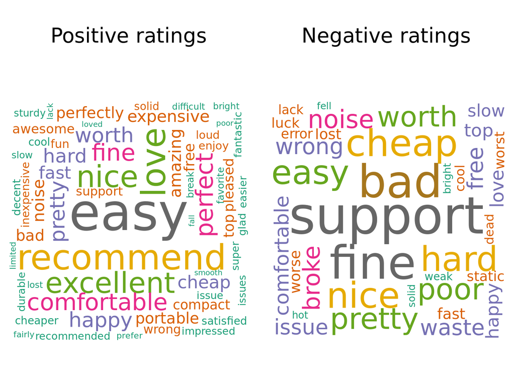

```r
layout(matrix(c(1:4), nrow=2, ncol = 2), heights=c(1, 4))
par(mar=rep(0, 4))
plot.new()
text(x=0.5, y=0.5, "Positive ratings", cex=2)

wordcloud(words = emo_pos$word, freq = emo_pos$n, scale=c(5,0.5), max.words=100, random.order=FALSE, rot.per=0.35, use.r.layout=FALSE, colors=brewer.pal(8, "Dark2"))

plot.new()
text(x=0.5, y=0.5, "Negative ratings", cex=2)

wordcloud(words = emo_neg$word, freq = emo_neg$n, scale=c(5,0.5), max.words=100, random.order=FALSE, rot.per=0.35, use.r.layout=FALSE, colors=brewer.pal(8, "Dark2"))
```

Many negative words are found in positive ratings. This is due to the negations and polarity inverter adjectives. For example : Not bad, would account for negative.

```r
# more examples of false positives

Z %>% filter(rating == 0 & y_hat >= 0) %>%
      sample_n(10) %>%
      mutate(reviewText = substring(reviewText,1,66),
             y_hat = ( y_hat >= 0) + 0
             ) %>%
      kable
```

| id | negative | positive | reviewText | rating | y_hat |
| --- | --- | --- | --- | --- | --- |
| 1526 | 29 | 55 | update 2-sep-13:put on cm 10. 2.2 (android 4. 2.2) last week. i’ve | 0 | 1 |
| 1336 | 8 | 11 | when b&n; designed this one, they were putting together a reading | 0 | 1 |
| 30605 | 1 | 2 | i loved my old cannon sure shot. when it was time to replace this | 0 | 1 |
| 1908 | 1 | 1 | this is the nook i dont like. .it doesnot habe light to let you re | 0 | 1 |
| 14998 | 0 | 4 | i recieved this camera a couple of days ago and i am very impresse | 0 | 1 |
| 5678 | 2 | 2 | i use this with my note ii fairly frequently. sometimes it works g | 0 | 1 |
| 1798 | 1 | 1 | this was my 3rd nook. .. i liked the features, but there seems to | 0 | 1 |
| 19255 | 0 | 5 | i bought this radio as a portable cb that i can take on my motorcy | 0 | 1 |
| 20649 | 2 | 2 | the maxell vp-100 vhs dry tape head cleaner came broken. i would n | 0 | 1 |
| 31505 | 5 | 7 | after using this keyboard for several months, i have concluded tha | 0 | 1 |

In the next portion, we’ll try to use NLP to enhance our classification.

## 1.4 A more sophisticated Classification

In the following, we’ll experiment with a 1-star rated wireless charger from Amazon. This particular review would count for a positive prediction using models that do not take into account the semantics:

Fix punctuation issues in this example “best.I” using `gsub` from the `stringr` package.

```r
txt <- c("Bought it in Black Friday sales for good price.I don't like it.not wanna recommend to anybody.")
#txt <- c("no problems!")

txt <- gsub( "([\\.\\,\\!\\?])([^ ]+)", "\\1 \\2", txt)
s <- as.String(txt)
```

## 1.5 Sentence chunking and Part-of-Speech tagging

The first step is to extract 2 types of phrases : - Verbal phrases that may imply opinions. Example : “I didn’t like the design” - Noun phrases that may describe the product. Example : The design was not good“”

The part-of-speech tags meaning is found in the [Penn Treebank Project](https://www.ling.upenn.edu/courses/Fall_2003/ling001/penn_treebank_pos.html)

Extracting Sentences POS tagging

```r
sent_token_annotator <- Maxent_Sent_Token_Annotator()
word_token_annotator <- Maxent_Word_Token_Annotator()
parse_annotator <- Parse_Annotator()
pos_tag_annotator <- Maxent_POS_Tag_Annotator()

a2 <- annotate(s, list(sent_token_annotator, word_token_annotator,pos_tag_annotator))
```

This `parse2graph` code is courtesy from (StackOverflow)[http://stackoverflow.com/questions/33473107/visualize-parse-tree-structure]

Visualize the sentences in a treebank

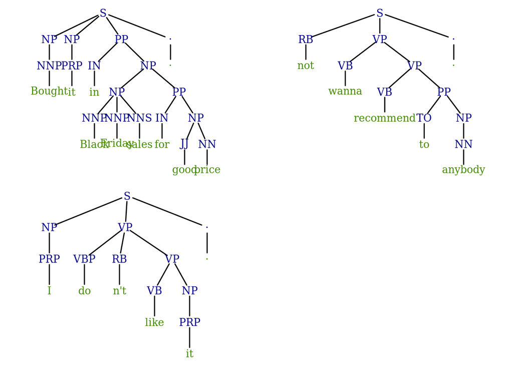

```r
invisible({
  ## extract tree annotations
  p <- parse_annotator(s, a2)
  ptext <- sapply(p$features, `[[`, "parse")

  ## define a layout
  layout(matrix(c(1:4), nrow=2, ncol = 2), heights=c(1, 1))
  par(mar=rep(0, 4))

  ## draw sentences
  lapply(ptext, function (t) {
  parse2graph(t,  # plus optional graphing parameters
            vertex.color=NA, vertex.frame.color=NA,
            vertex.label.font=1, vertex.label.cex=1,
            edge.label.cex=4, edge.width=1.5, edge.color='black', edge.arrow.size=0)
  })
  par(resetLayout())
})
```

As we can see from the graphs, the ideal approach is to score each leaf and propagate the scores (like in Stanford’s NLP engine). But let’s keep it simple and propagate the negations from Adverbs to verbs and adjectives that have sentiments on them, namely negation-of-adjective (NOA) and negation-of-verb (NOV).

Transform it to [word, part-of-speech-tag] dataframe

```r
words <- subset(a2, type == "word")

chk_df <- as.data.frame(words) %>%
  dplyr::mutate(word = s[words],
         tag1 = sapply(features, '[[', "POS"),
         tag = substring(tag1,1,2) ## remove verb tense
         ) %>%
  dplyr::select (word,tag)

## preview
chk_df %>% head(10) %>% kable
```

| word | tag |
| --- | --- |
| Bought | NN |
| it | PR |
| in | IN |
| Black | NN |
| Friday | NN |
| sales | NN |
| for | IN |
| good | JJ |
| price | NN |
| . | . |

### 1.5.1 Feature identification

For the purpose of this work we won’t go for a full analysis using penn treebanks. Rather we’ll simply identify the following words inside a verbal and noun chunks (phrase):

- [VB] : verb w/ positive/negative sentiment : like, hate , etc
- [JJ] : adjective w/ positive/negative sentiment : bad, junk
- [RB] : adverb polarity inverter such as : n’t, or incr/decrementers such as : too, very, more etc.

First, let’s use `tidytext` `sentiments`

```r
dict <- sentiments %>%
        filter(lexicon == "bing" & sentiment %in% c("negative", "positive"))  %>%
        dplyr::select(word,sentiment)
```

Transform each sentiment to it’s score (+1, -1)

```r
dict$sentiment <- as.numeric( mapvalues(dict$sentiment,
          from=c("negative","positive"),
          to=c(-1,1)))
```

Next prepare inverter and incrementer/decrementers maps

```r
## inverters
inv_  <- c("never", "no", "nothing", "nowhere", "noone", "none", "not", "n't")
inv_ <- data.frame(word = as.character(inv_), multiplier = rep(-1, length(inv_)), stringsAsFactors = F)

## incrementer/decrementers
inc_ <- c("too", "very", "extremly", "badly", "poorly" )
inc_ <-  data.frame(word = as.character(inc_), multiplier = c(2,2,2,.5,.5), stringsAsFactors = F)

#dico <- rbind(inv_,inc_)
```

Let’s apply the scores and multipliers using `left_join`

```r
wds <- chk_df %>% left_join(dict) %>% left_join(inv_)
wds$sentiment[is.na(wds$sentiment)] <- 0
```

## 1.6 Scoring algorithm

The idea is to find RB multiplier and look for a VB or JJ surrounding it :

For example : n’t like : will compute 1 x -1

```r
## find adverbs :
wds.RB <- which(wds$tag %in% c("RB", "DT") & !is.na(wds$multiplier))
wds.len <- nrow(wds)
lapply(wds.RB, function (i){
    k <- i+1
    while (k<=wds.len & k<=i+2) {
      if (wds$tag[k] %in% c("JJ","VB", "NN")) {
          wds$sentiment[k] <<-  wds$sentiment[k] * wds$multiplier[i]
      }
      k <- k + 1
    }
})
```

```r
wds
```

```
##         word tag sentiment multiplier
## 1     Bought  NN         0         NA
## 2         it  PR         0         NA
## 3         in  IN         0         NA
## 4      Black  NN         0         NA
## 5     Friday  NN         0         NA
## 6      sales  NN         0         NA
## 7        for  IN         0         NA
## 8       good  JJ         1         NA
## 9      price  NN         0         NA
## 10         .   .         0         NA
## 11         I  PR         0         NA
## 12        do  VB         0         NA
## 13       n't  RB         0         -1
## 14      like  VB        -1         NA
## 15        it  PR         0         NA
## 16         .   .         0         NA
## 17       not  RB         0         -1
## 18     wanna  VB         0         NA
## 19 recommend  VB        -1         NA
## 20        to  TO         0         NA
## 21   anybody  NN         0         NA
## 22         .   .         0         NA
```

```r
sum(wds$sentiment)/sum(wds$sentiment != 0)
```

```
## [1] -0.3333333
```

## 1.7 Generalization

Let’s wrap all above into a function

```r
estimate_sentiment = function(x) {
      x <- as.String(x)
      a2 <- annotate(x, list(sent_token_annotator, word_token_annotator,pos_tag_annotator))
      words <- subset(a2, type == "word")

      chk_df <- as.data.frame(words) %>%
            dplyr::mutate(word = x[words],
               tag1 = sapply(features, '[[', "POS"),
               tag = substring(tag1,1,2) ## remove verb tense
               ) %>%
            dplyr::select (word,tag)
      wds <<- chk_df %>% left_join(dict, by="word") %>% left_join(inv_, by="word")
      wds$sentiment[is.na(wds$sentiment)] <- 0
      ## find adverbs :
      wds.RB <- which(wds$tag %in% c("RB", "DT") & !is.na(wds$multiplier))
      wds.len <- nrow(wds)
      lapply(wds.RB, function (i){
          k <- i+1
          while (k<=wds.len & k<=i+2) {
            if (wds$tag[k] %in% c("JJ","VB", "NN")) {
                wds$sentiment[k] <<-  wds$sentiment[k] * wds$multiplier[i]
            }
            k <- k + 1
          }
      })
      list(positive = sum(wds$sentiment > 0) , negative = sum(wds$sentiment < 0))
}
```

Apply it to a number of review texts .

```r
xtract <- df %>% filter(nchar(reviewText) > 8)  %>% sample_n(2000)
senti <- lapply(xtract$reviewText, estimate_sentiment)

X <- data.frame( y = xtract$rating,
                  negative = sapply(senti, '[[', "negative"),
                  positive = sapply(senti, '[[', "positive"),
                 text = xtract$reviewText)

X_h <- X %>% dplyr::mutate(y_hat = (positive-negative)/(positive+negative+1))
```

Accuracy

```r
table(X_h$y ,  (X_h$y_hat > 0) + 0)
```

```
##
##       0   1
##   0 546 461
##   1 149 844
```

```r
accuracy(X_h$y,  (X_h$y_hat > 0) + 0)
```

```
## [1] 0.695
```

```r
## misses

X_h %>%  filter(y != (X_h$y_hat > 0) + 0) %>%
      sample_n(10) %>%
      mutate(text = substring(text,1,66),
             y_hat = ( y_hat >= 0) + 0
             ) %>%
      kable
```

| y | negative | positive | text | y_hat |
| --- | --- | --- | --- | --- |
| 1 | 1 | 1 | i have not yet purchased the bel 980 but i do plan on it! i’m just | 1 |
| 1 | 2 | 2 | this is the best of the low priced router’s on the market. only co | 1 |
| 0 | 3 | 5 | i purchased this cable since the printers now require one, and do | 1 |
| 0 | 3 | 5 | this headset sounded great on my 2. 4 ghz uniden cordless phone. i | 1 |
| 1 | 12 | 6 | we had a tv/vcr combo that made pulling the vcr apart to clean it | 0 |
| 0 | 2 | 6 | +’s: small, looks cool, good sound quality-’s: i am running win 98 | 1 |
| 0 | 1 | 5 | i ordered this product and it’s great - however, if you have windo | 1 |
| 0 | 10 | 12 | i recently came across the top-of-the-line sony portable minidisc | 1 |
| 0 | 1 | 3 | i have now used these headphones on a few flights and have found t | 1 |
| 0 | 1 | 2 | hello! thinking of the meade ds 114, 4. 5" reflector? it’s a | 1 |

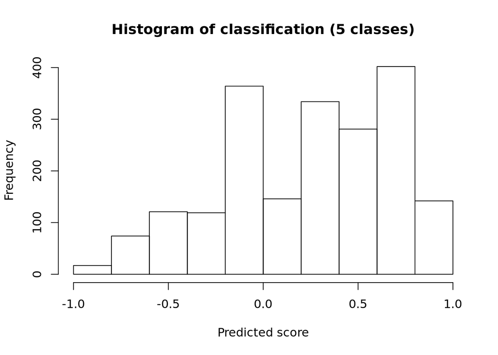

```r
##

hist(X_h$y_hat,
     main="Histogram of classification (5 classes)",
     xlab="Predicted score")
```

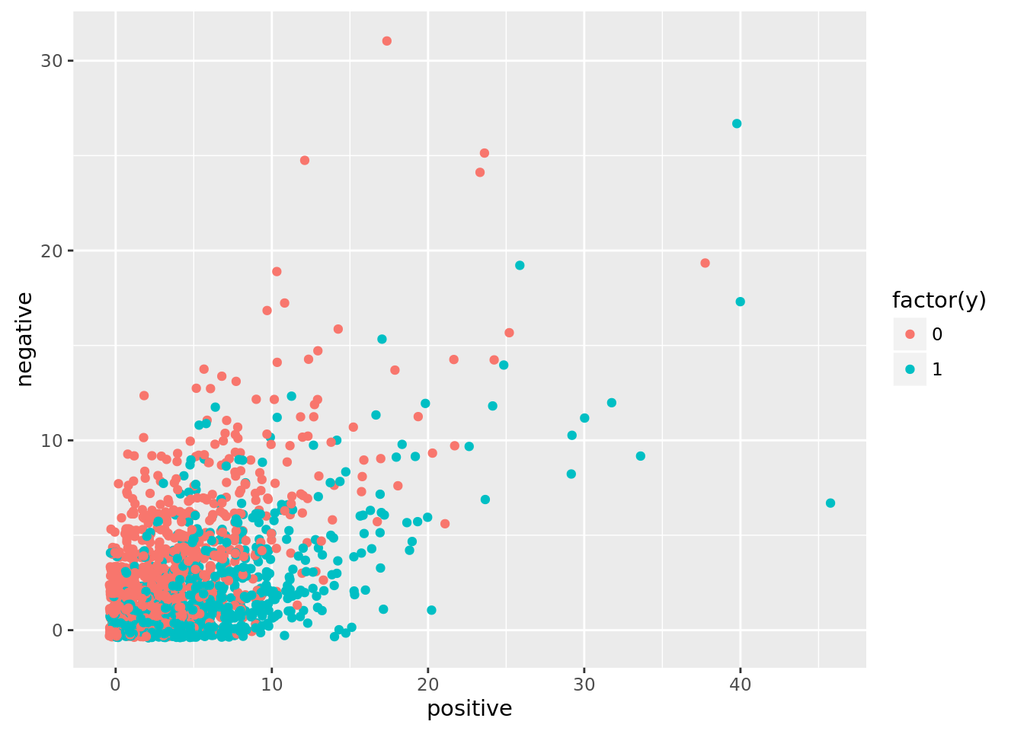

```r
X_h  %>%
    ggplot(aes(positive, negative, color=factor(y))) +
    geom_jitter()
```

## 1.8 Interpretation

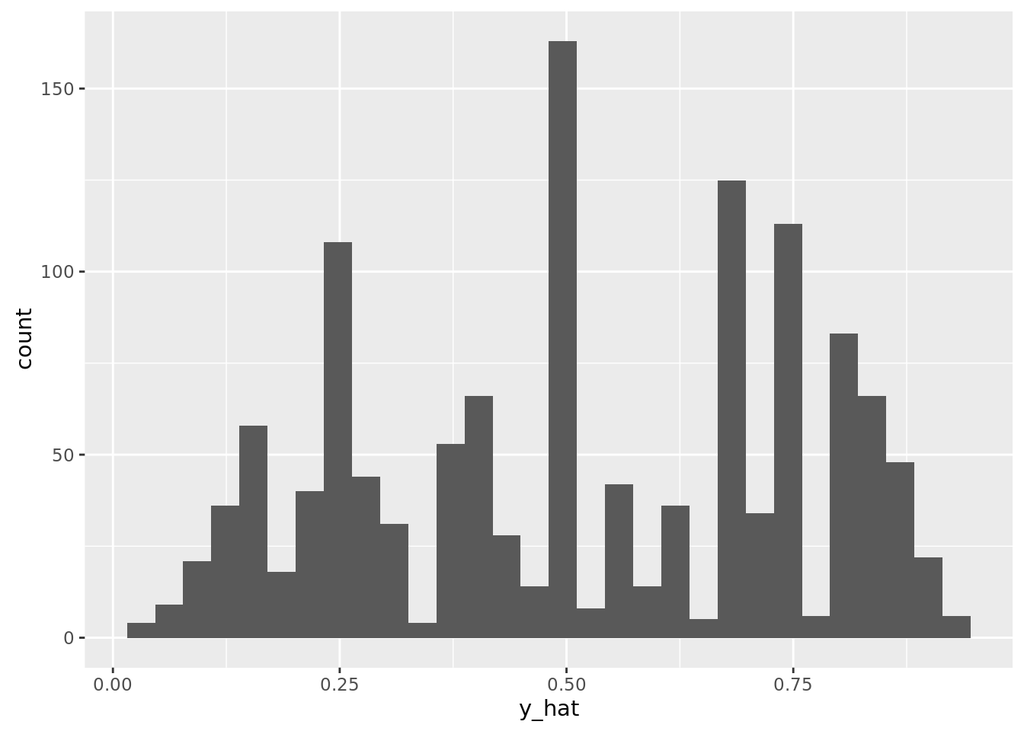

```r
# plot the distribution of positive ,

X_h %>% filter(y_hat > 0) %>% ggplot(aes(y_hat)) + geom_histogram()
```

```r
# Due to heavy calculation cost we can't process large number of samples. But should look like a normal distribution. Then we can calculate the mean and sd
```

## 1.9 GLM :

```r
## glm
glm.model <- glm(y~positive + negative, data=X, family=binomial)

glm.pred <- predict(glm.model, newdata=X, type="response")
summary(glm.model)
```

```
##
## Call:
## glm(formula = y ~ positive + negative, family = binomial, data = X)
##
## Deviance Residuals:
##     Min       1Q   Median       3Q      Max
## -2.6524  -0.9277  -0.1054   0.9108   2.9484
##
## Coefficients:
##             Estimate Std. Error z value Pr(>|z|)
## (Intercept) -0.26348    0.07670  -3.435 0.000592 ***
## positive     0.32145    0.01927  16.680  < 2e-16 ***
## negative    -0.49989    0.02913 -17.158  < 2e-16 ***
## ---
## Signif. codes:  0 '***' 0.001 '**' 0.01 '*' 0.05 '.' 0.1 ' ' 1
##
## (Dispersion parameter for binomial family taken to be 1)
##
##     Null deviance: 2772.5  on 1999  degrees of freedom
## Residual deviance: 2227.5  on 1997  degrees of freedom
## AIC: 2233.5
##
## Number of Fisher Scoring iterations: 5
```

```r
## compute lr confusion matrix assuming a cutoff at 0.5
table(X$y, glm.pred>.5)
```

```
##
##     FALSE TRUE
##   0   726  281
##   1   254  739
```

```r
## compute lr accuracy
accuracy(X$y, glm.pred>.5)
```

```
## [1] 0.7325
```

## 1.10 Random Forest

```r
require(randomForest)
rf.fit <- randomForest(as.factor(y) ~ positive + negative,
                       data=X,
                       importance=TRUE,
                       mtry = 3,
                       ntree=2000)

rf.pred <- predict(rf.fit, newdata = X, type="response" )

## compute confusion matrix
table(as.factor(X$y), rf.pred )
```

```
##    rf.pred
##       0   1
##   0 763 244
##   1 232 761
```

```r
## compute accuracy
rf.accuracy <- accuracy(as.factor(X$y), rf.pred );rf.accuracy
```

```
## [1] 0.762
```

# 2 Conclusion

But, some language forms require a deep analysis. For example :

Sarcasm : “Great sound when working” Deep inverter : “Not such a good value after all”, polarity inverter adverb is 3-words faraway from its adjective.